# Probability Theory

Yuji Saikai ysaikai@unimelb.edu.au School of Mathematics and Statistics The University of Melbourne

These notes are based on Chapter 13 & 14 of JMR — Jones, O., Maillardet, R., & Robinson, A. (2009). *Introduction to scientific programming and simulation using R*. CRC Press.

# Probability

Probability is an essential tool for developing and interpreting stochastic simulations, which are very useful for gaining insight about situations that are too complex to analyse theoretically. Probability theory starts with the axioms of mathematical structure that allows us to model experiments with random outcomes and quantify the likelihood of each result of the experiments.

> In these notes, to minimise distractions, I try to avoid measure-theoretic notions, which are fundamental to the rigorous probability theory. For our purpose, benefits are much bigger than costs. For example, technically speaking, not all subsets of the unit interval $[0,1]$ qualify as events, because the power set is too large to assign a probability to each element. The most common collection, which is somewhat smaller but not too small to be useful, is called the Borel $\sigma$-algebra.

## Sample space & events

- Sample space : the set of all possible outcomes
- Sample point : an element of sample space
- Event : a subset of sample space

For example, imagine an experiment in which we roll a die. The sample space is $\{1,2,3,4,5,6\}$. Any combination of six numbers (or lack thereof) such as $\{2,4,6\}$ and $\{1\}$ is an event. In this case, therefore, a collection of all events is a [power set](https://en.wikipedia.org/wiki/Power_set) of size $2^6=64$. While this is a straightforward case, how we define sample space is often important. For example, if we roll a die twice (or roll two dice at once), we have two reasonable choices: ordered or unordered pairs. The choice probably depends on how we model problems of interest.

## Notaitons & set operations

Notations:

- $\Omega$ : sample space
- $\omega$ : sample point
- $A$, $B$, … : events
- $\emptyset$ : empty set
- $|A|$ : number of elements in $A$

Basic operations on sets

- $A\setminus B = \{\omega\in\Omega : \omega \in A \;\text{ and }\; \omega \notin B\}$
- $\overline{A} = \Omega\setminus A$
- $A\cup B = \{\omega\in\Omega : \omega \in A \;\text{ or }\; \omega \in B\}$
- $A\cap B = \{\omega\in\Omega : \omega \in A \;\text{ and }\; \omega \in B\}$
- $\overline{A\cup B} = \overline{A} \cap \overline{B}$
- $\overline{A\cap B} = \overline{A} \cup \overline{B}$

When it comes to simple set operations, Venn diagram is our friend.

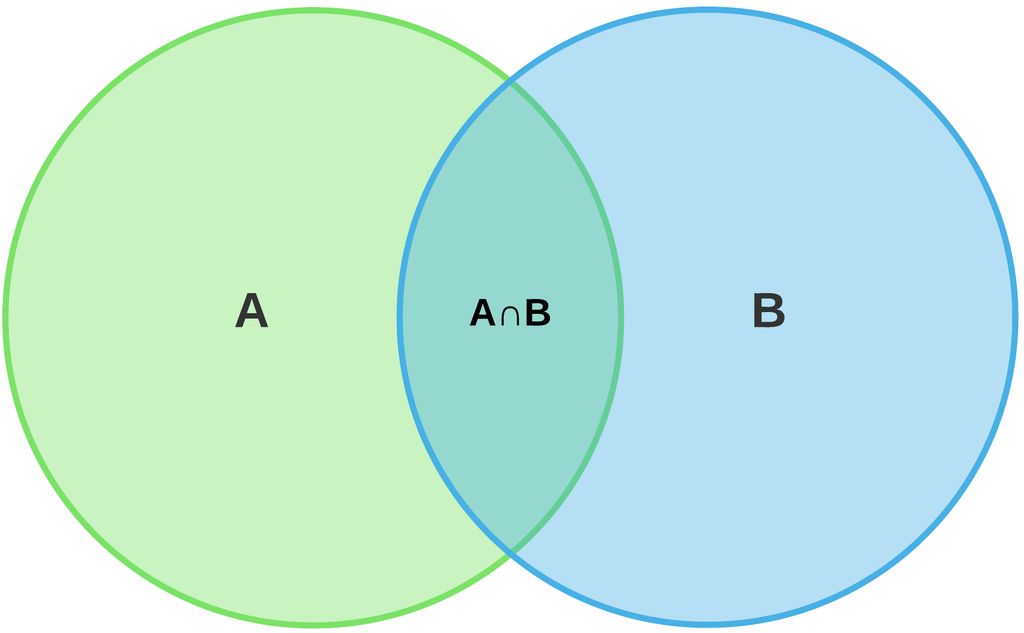

## Probability function

A probability function $P$ assigns a value in $[0,1]$ to an event $A\subseteq\Omega$. Intuitively, $P(A)$ is the answer to the question of *How likely is event $A$?* A probability function $P$ must be **constructed** to satisfy the following three properties:

- $0\leq P(A)\leq 1$ for $A\subseteq\Omega$
- $P(\emptyset) = 0$ and $P(\Omega) = 1$
- For a collection of mutually exclusive events $\{A_k\}$ for $k\in\{1,2,\dots\}$,
  $$P\left(\bigcup_k A_k\right) = \sum_k P(A_k) .$$

> $\bigcap_k A_k = \emptyset$ if $\{A_k\}$ is a collection of mutually exclusive events.

### Examples

Suppose $\Omega$ is a finite set of size $|\Omega|=n$. If our model is that each element is equally likely, then,
$$P(A) = \frac{|A|}{n} .$$
In other words, we just need to count the elements of $A$ to compute $P(A)$.

In contrast, in an experiment of rolling an unfair die with $6$ twice more likely than the others, we have the following probability function:

| $\omega$ | $1$ | $2$ | $3$ | $4$ | $5$ | $6$ |
| --- | --- | --- | --- | --- | --- | --- |
| $P(\{\omega\})$ | 1/7 | 1/7 | 1/7 | 1/7 | 1/7 | 2/7 |

## Conditional probability

I roll a die. You predict and shout out “#1!”. Your chance to get it right is $1/6$. OK.

Next, I roll a die, and you shout out “#1!” again (perhaps because you like #1). But this time, I tell you I have got an odd number. Now, you suddenly have a better chance, don’t you?

We can model this experiment as follows:

- $\Omega = \{1,2,3,4,5,6\}$
- $A = \{1\}$
- $B = \{1,3,5\}$

Your better chance is called a *conditional probability* and computed as follows:
$$P(A|B) = \frac{P(A\cap B)}{P(B)} = \frac{P(A)}{P(B)} = \frac{1/6}{1/2} = \frac{1}{3} .$$

> Note $A\cap B = A$ because $A\subset B$.

Perhaps, it makes more sense if we write $P(A\cap B) = P(A|B)P(B)$. The probability that both $A$ and $B$ happen is equal to the probability that $B$ happens first and, treating *$B$ as a new sample space*, $A$ happens next. In other words, provided $P(B)>0$, we can restrict the sample space $\Omega$ to $B$ and use $P(\cdot|B)$ as a legitimate probability function that takes a subset of $B$ and returns a value in $[0,1]$.

## Independence

Two events $A$ and $B$ are said to be independent if $P(A\cap B) = P(A)P(B)$. To interpret probabilistic independence, the following equivalence often helps. Provided $P(B)>0$, we have
$$\begin{alignat}{2}
&& P(A\cap B) &= P(A)P(B)\\
&\Leftrightarrow\quad& P(A|B)P(B)&=P(A)P(B)\\
&\Leftrightarrow\quad& P(A|B)&=P(A),
\end{alignat}$$
which we may read as *Restricting the sample space to $B$ or knowing $B$ happened first does not change the probability of $A$.*

### Example

To get some intuition, think of rolling two dice, one in red and the other in blue. $\Omega$ is the collection of all the ordered pairs:
$$\Omega = \{\omega=(\omega_r,\omega_b) : \omega_r,\omega_b\in\{1,2,\dots,6\}\} .$$
Now, suppose:
$$A = \{\omega=(\omega_r,\omega_b) : \omega_r = 1\}$$
and
$$B = \{\omega=(\omega_r,\omega_b) : \omega_b = 6\} .$$
If you roll the red die first and see $1$ up (i.e., $A$ happened), is the probability that the blue die turns with $6$ up different from $1/6$? No, it should not be. Concretely, when the sample space is $\Omega$, the size of $B$ is
$$|B| = |\{(1,6),(2,6),\dots,(6,6)\}| = 6 .$$
In contrast, when the sample space is $A$, the size of $B$ is
$$|B \text{ given } A| = |\{(1,6)\}| = 1 .$$
Hence,
$$P(B) = \frac{|B|}{|\Omega|} = \frac{6}{36} = \frac{1}{6} = \frac{|B \text{ given } A|}{|A|} = P(B|A) .$$

## Law of total probability

A partition of a set $\Omega$ is a collection of non-empty subsets $E_1,E_2,\dots$ such that every element $\omega\in\Omega$ is in exactly one of these subsets. In other words, the sample space is a union of mutually exclusive events:
$$\Omega = \bigcup_k E_k .$$
Partitioning helps us split a complex event $A$ into a sequence of simpler events $A\cap E_1$, $A\cap E_2$, $\dots$. This leads to the law of total probability.

Suppose events $E_1,E_2,\dots,E_K$ partitions the sample space $\Omega$. Then,

$$\begin{align}
P(A) &= P(A\cap\Omega)\\
&= P(A\cap(E_1\cup E_2\cup\dots\cup E_K))\\
&= P((A\cap E_1)\cup(A\cap E_2)\cup\dots\cup(A\cap E_K))\\
&= P(A\cap E_1)+P(A\cap E_2)+\dots+P(A\cap E_K)\\
&= P(A|E_1)P(E_1)+P(A|E_2)P(E_2)+\dots+P(A|E_K)P(E_K)
\end{align}$$

## Bayes’ formula

Using the conditional probability formula, $P(A\cap B)$ can be expressed in two ways:

- $P(A\cap B) = P(B|A)P(A)$
- $P(A\cap B) = P(A|B)P(B)$

Equating them, we can get
$$P(B|A) = \frac{P(A|B)P(B)}{P(A)}.$$
Or, using a partition $\Omega = E_1\cup\dots\cup E_K$ and setting $B=E_k$ for some $k\in\{1,2,\dots,K\}$,
$$\begin{align}
P(E_k|A) &= \frac{P(A|E_k)P(E_k)}{P(A)}\\
&= \frac{P(A|E_k)P(E_k)}{P(A|E_1)P(E_1)+\dots+P(A|E_K)P(E_K)}
\end{align}$$
which is given a special name — Bayes’ formula (a.k.a. Bayes’ rule or theorem).

A few comments:

- Bayes’ formula allows us to turn around conditional probabilities from $P(A|E_k)$ to $P(E_k|A)$. This can be useful. For instance, $E_1,\dots,E_K$ are competing hypotheses, and we may have information $P(A|E_k)$ for each hypothesis. Then, $A$ can be used as evidence to assess their probabilities $P(E_k|A)$.
- In Bayesian statistics, $P(E_k)$ is called **prior** information, while $P(E_k|A)$ is called **posterior** information. Bayes’ formula updates the prior to the posterior using collected data $A$ and $P(A|E_k)$ as the **likelihood** of observing $A$ under $E_k$.

### Example

Suppose we have a COVID test that detects coronavirus $96\%$ of the time, but gives false positives $2\%$ of the time. Assume that $5\%$ of the population carries the virus. If a random person tests positive, what is the probability that he/she actually carries the virus?

First, define the following events.

- $A$ : Person tests positive.
- $E_1$ : Person has the virus.
- $E_2$ : Person does not have the virus.

(N.B. $E_2 = \overline{E}_1$.) Then, we are given the following probabilities:
$$P(A|E_1) = \frac{96}{100},\quad P(A|E_2) = \frac{2}{100},\quad P(E_1) = \frac{5}{100} .$$
Now, applying Bayes’ formula,
$$P(E_1|A) = \frac{\frac{96}{100}\cdot\frac{5}{100}}{\frac{96}{100}\cdot\frac{5}{100}+\frac{2}{100}\cdot\frac{95}{100}} \approx 0.716 .$$
Probably, the most critical piece of information is what proportion of the population carries the virus. If our estimate changes from 5% to 1%, then we have $P(E_1|A)\approx 0.327$. If the positive result implied only 33% chance of infection, I expect, much of public policies and people’s behaviour would be different.

# Random variables

When modelling practical problems, it is often the case that random outcomes are expressed in numerical values and/or we are interested in attaching numerical values to random outcomes. For example, when rolling a pair of dice, it may be the sum of two dice that is of interest. Random variable is a mathematical device for this purpose.

## Definition

Given the sample space $\Omega$ and probability function $P$, a random variable $X$ is a **function** that maps a sample point to a real number, $X : \Omega \to \mathbb{R}$.

> I know it’s weird. As opposed to lower case letters, a capital letter $X$ is used for a function yet called “variable”. Despite the name “random” variable, it is just a deterministic function. Unfortunately, this is the convention.

Let $A$ be a subset of the real line. Then, to express the probability that “$X$ lies in $A$”, we write $P(X\in A)$ as a shorthand for $P(\{\omega\in\Omega : X(\omega)\in A\})$.

### Example

Using the example of rolling two dice, we illustrate four random variables:

- $X_1$ : Outcome of the red die
- $X_2$ : Outcome of the blue die
- $X_3$ : Sum of two dice
- $X_4$ : Number of rolls that give one or two

Formally,
$$X_1(\omega_r,\omega_b) = \omega_r,\; X_2(\omega_r,\omega_b) = \omega_b,\; X_3(\omega_r,\omega_b) = X_1+X_2 = \omega_r+\omega_b .$$
To express $X_4$, let us first introduce an **indicator function** of a set $B$. It takes $x$ as an argument and returns
$$\mathbb{1}_B(x) =
\begin{cases}
1, & \text{if } x\in B\\
0, & \text{if } x\notin B
\end{cases}.$$
With this, we may write
$$X_4(\omega_r,\omega_b) = \mathbb{1}_{\{1,2\}}(\omega_r) + \mathbb{1}_{\{1,2\}}(\omega_b) .$$
Now, suppose a random outcome turns out $\omega=(1,6)$. Then, we have the following realizations of the random variables:
$$X_1(1,6) = 1,\; X_2(1,6) = 6,\; X_3(1,6) = 7 ,$$
and
$$X_4(1,6) = \mathbb{1}_{\{1,2\}}(1) + \mathbb{1}_{\{1,2\}}(6) = 1 + 0 = 1 .$$
How about the probability that the sum of two dice is equal to a specific value, say 8? First, realize that each element of the event $\{(\omega_r,\omega_b):\omega_r+\omega_b=8\}$ is equally likely. So, this is a counting problem, and we have five possible outcomes: $(2,6)$, $(3,5)$, $(4,4)$, $(5,3)$, and $(6,2)$. Thus,
$$\begin{align}
P(X_3=8) &= P(\{(\omega_r,\omega_b) : \omega_r+\omega_b = 8\})\\
&= \frac{5}{36}
\end{align}$$

> When interested in an event where $X$ lies in a singleton set, we often write $P(X=x)$ to mean $P(X\in\{x\})$.

### Independence

We can extend the concept of independent events to independent random variables. Random variables $X$ and $Y$ are independent if any event defined using $X$ is independent of any event defined using $Y$. That is, for any sets $A$ and $B$, the events $\{X \in A\}$ and $\{Y \in B\}$ are independent.

Independence is usually an assumption that we make based on our understanding of the random process in question, rather than something we try to prove.

## Cumulative distribution function

The cumulative distribution function (CDF) of a random variable $X$ is defined by
$$F(x) = P(X\leq x)\; \text{ for all } x\in\mathbb{R}.$$
The weak inequality $\leq$ implies that the CDF specifies a probability of a left-open right-closed interval $(a,b]$:
$$P(X\in(a,b]) = P(a<X\leq b) = F(b)-F(a) .$$
Since $(a,b]\subset\mathbb{R}$ is arbitrary, using combinations of such intervals, we can describe a probability that $X$ lies in any (legitimate) subset. An important implication is that *a random variable can be described by the CDF without referring to the underlying sample space and probability function*.

We may plot the CDF of $X_3$ as follows.

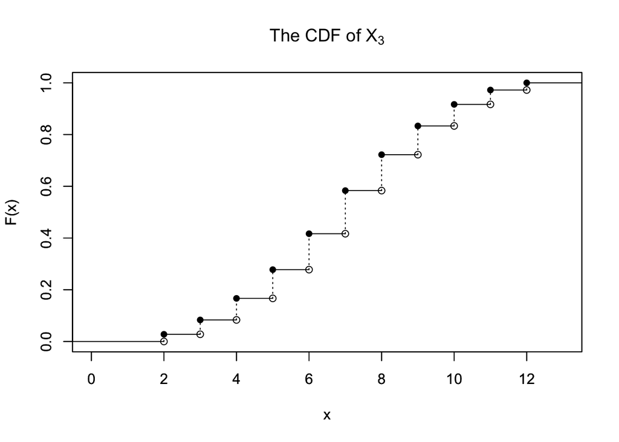

```r
x <- 2:12
y1 <- c(1,3,6,10,15,21,26,30,33,35,36)/36
plot(x, y1, xlim=c(0,13), ylim=c(0,1), ylab="F(x)", pch=16)
par(new=TRUE)
y2 <- c(0,y1[1:10])
plot(x, y2, xlim=c(0,13), ylim=c(0,1), ylab="F(x)")
segments(x[1:10], y1[1:10], x[2:11], y1[1:10])
segments(c(2,12), c(0,1), c(-1,14), c(0,1))
segments(x, y2, x, y1, lty=3)
title(expression("The CDF of X"[3]))
```

> We use notations $f(a-)$ and $f(a+)$ to mean the limit of $f(x)$ as $x$ approaches $a$, respectively, from the left and from the right.

> By definition, CDF is always right-continuous $F(x) = F(x+)$. So, if $F(x) = F(x-)$, then, $F$ is continuous at $x$.

## Types of random variables

### Discrete

A random variable $X$ is said to be **discrete** if there exists a finite or countably infinite set $B\subset\mathbb{R}$ such that $P(X \in B) = 1$. The definition implies that the CDF of $X$ is a step function that jumps at each element of $B$. For example, as seen in the above figure, the CDF of $X_3$ has 11 jumps and is flat for the rest.

The **probability mass function** (PMF) of a discrete random variable $X$ is the function $p$ defined by
$$p(x) = P(\{\omega\in\Omega : X(\omega)=x\})$$
for all $x\in\mathbb{R}$. The PMF is related to the CDF as follow:
$$p(x) = F(x)-F(x-).$$
In other words, $p(x)$ is equal to the height of jump at $x$.

### Continuous

If a non-negative function $f$ on $\mathbb{R}$ satisfies
$$P(X\leq x) = F(x) = \int_{-\infty}^x f(y)dy$$
for all $x\in\mathbb{R}$, then $f$ is a **probability density function** (PDF) for $X$. A random variable $X$ is said to be (absolutely) **continuous** if $X$ has a PDF.

> Technically speaking, a PDF for $X$ is not unique, because integral is insensitive to a countable set of points in the integration range. For example, $f_1(x) = \mathbb{1}_{[0,1]}(x)$ and $f_2(x) = \mathbb{1}_{[0,1]\setminus\{0.5\}}(x)$ are both legitimate PDFs for the uniform distribution over $[0,1]$. In practice, however, we often say **the** PDF for $X$ to refer to the nicest continuous one.

An implication is that the CDF of $X$ is a continuous function and $F(x) = F(x-)$ for all $x\in\mathbb{R}$. Thus,
$$P(X=x) = F(x)-F(x-) = 0 .$$

## Random vectors

As done above, we can define multiple random variables on the same sample space $\Omega$ and probability function $P$. We may put together $X_1, X_2,\dots, X_d$ and call it a random vector $\mathbf{X} = (X_1, X_2,\dots, X_d)$. Since each $X_d$ takes a value $x\in\mathbb{R}$, $\mathbf{X}$ takes a vector $\mathbf{x}\in\mathbb{R}^d$.

The concepts for random variables are naturally generalized to random vectors.

- The probability that $\mathbf{X}$ lies in $A\subset\mathbb{R}^d$ is
  $$P(\mathbf{X}\in A) = P(\{\omega\in\Omega : \mathbf{X}(\omega)\in A\}) .$$
- The **joint** PMF for $\mathbf{X}$ is
  $$p(\mathbf{x}) = P(\mathbf{X}=\mathbf{x}) = P(X_1=x_1,X_2=x_2,\dots,X_d=x_d).$$
- A non-negative function $f$ on $\mathbb{R}^d$ is a **joint** PDF for $\mathbf{X}$ if $f$ satisfies
  $$P(X_1\leq x_1,\dots,X_d\leq x_d) = \int_{-\infty}^{x_1}\dots\int_{-\infty}^{x_d}f(y_1,\dots,y_d)dy_1\dots dy_d.$$

### Marginalisation

Marginalisation follows from the law of total probability. The marginal PMF of $X_k$ is obtained by summing the joint PMF over all possible values of the other random variables with fixed $X_k=x_k$:
$$p_{X_k}(x_k) = \sum_{x_1,\dots,x_{k-1},x_{k+1},\dots,x_d} p(x_1,\dots,x_{k-1},x_k,x_{k+1},\dots,x_d) .$$

A marginal PDF of $X_k$ is defined analogously:
$$f_{X_k}(x_k) = \int_{-\infty}^{\infty}\dots\int_{-\infty}^{\infty}f(x_1,\dots,x_{k-1},x_k,x_{k+1},\dots,x_d)dx_1\dots dx_{k-1}dx_{k+1}\dots dx_d .$$

> We can also marginalise to more than 1-dimensional PMF/PDF by summing/integrating over all possible values of the random variables except those of interest.

### Conditional distribution

We can extend the concept of conditional probability to random variables. This is particularly straightforward for discrete random variables. A conditional PMF for $X_2$ given $X_1=x_1$ is
$$p_{X_2|X_1}(x_2|x_1) = P(X_2=x_2|X_1=x_1) = \frac{P(X_1=x_1,X_2=x_2)}{P(X_1=x_1)} = \frac{p(x_1,x_2)}{p_{X_1}(x_1)}.$$
Note that this is a function of only $x_2$ and $x_1$ is given and fixed. For continuous random variables, you can essentially mimic the above formula. A conditional PDF for $X_2$ given $X_1=x_1$ is
$$f_{X_2|X_1}(x_2|x_1) = \frac{f(x_1,x_2)}{f_{X_1}(x_1)}.$$

> We can also condition a random vector to another random vector.

### Mix of discrete and continuous random variables

We may also have a random vector that consists of both discrete and continuous random variables. In practice, this type of random vectors often arises when discrete random variables specify a category and, for each category, there are continuous random variables. For example, let $X_1$ be a discrete random variable and let $X_2$ be a continuous random variable. While the distribution for $X_1$ is provided as a usual PMF, the distribution for $X_2$ is provided in the form of a conditional PDF, which depends on the value of $X_1$. That is,
$$P(X_2\leq x_2|X_1=x_1) = \int_{-\infty}^{x_2} f_{X_2|X_1}(y_2|x_1)dy_2.$$
In this case, the joint distribution is
$$\begin{align}
P(X_1=x_1, X_2\leq x_2) &= \int_{-\infty}^{x_2} f(x_1, y_2)dy_2\\
&= \int_{-\infty}^{x_2} f_{X_2|X_1}(y_2|x_1)p_{X_1}(x_1)dy_2
\end{align}$$
Marginalisation follows from the law of total probability in a similar way.
$$\begin{align}
p_{X_1}(x_1) &= \int_{-\infty}^{\infty} f(x_1, x_2)dx_2\\
&= \int_{-\infty}^{\infty} f_{X_2|X_1}(x_2|x_1)p_{X_1}(x_1)dx_2\\
f_{X_2}(x_2) &= \sum_{x_1} f(x_1, x_2)\\
&= \sum_{x_1} f_{X_2|X_1}(x_2|x_1)p_{X_1}(x_1).
\end{align}$$

## Expectation

Let’s consider a discrete random variable $X$, which takes a value $x$ with probability of $p(x)$. It makes sense to think about what value to expect from this random event. One intuitive value to expect is the average of all possible values, isn’t it? Moreover, since each possible value has its own associated probability, it is more reasonable to use the **weighted average** with $p(x)$ as a weight for $x$. Mathematical expectation formalises this intuition. For our purpose, it suffices to see expectation as a weighted average.

> In these notes, when discussing expectation, we implicitly assume it exists.

### Mean

The expectation $\mathbb{E}X$ of a discrete random variable $X$ is defined by
$$\mathbb{E}X = \sum_x xP(X=x) .$$
This is precisely the weighted average — each value $x$ is weighted by $p(x)$ and summed up while each weight $p(x)$ sums to $1$.

In the case of continuous $X$, summation over a countable set becomes integral over an uncountable set. In addition, each weight is provided by PDF $f(x)$, as it rightly “sums” (well, integrates) to $1$. Hence,
$$\mathbb{E}X = \int_{-\infty}^\infty xf(x)dx .$$

When there is no transformation of $X$, $\mathbb{E}X$ is called the **mean** of $X$.

### Transformation

We are often interested in $h(X)$, a transformation of $X$ using a deterministic function $h$, and its expectation $\mathbb{E}h(X)$. Here is the formula.
$$\mathbb{E}h(X) =
\begin{cases}
\sum_x h(x)p(x), & \text{if } X \text{ is discrete}\\
\int_{-\infty}^\infty h(x)f(x)dx, & \text{if } X \text{ is continuous}
\end{cases}$$

Remember the definition of random variable — a function mapping $\omega\in\Omega$ to $x\in\mathbb{R}$. Since a function of a function is just another function, $h(X)$ can be seen as another random variable (say, $Y=h(X)$). Finally, the probability of $h(X)=y$ is obtained by summing the probabilities of $X=x_i$ such that $h(x_i)=y$ for all $i$ because two sets $\{\omega\in\Omega : X(\omega)=x_i\}$ and $\{\omega\in\Omega : X(\omega)=x_j\}$ are mutually exclusive for distinct $i$ and $j$. The last point is seen at the second equality in the following proof for the discrete case.
$$\begin{align}
\mathbb{E}Y &= \sum_y y P(Y=y)\\
&= \sum_y y \sum_{x:y=h(x)} P(X=x)\\
&= \sum_y \sum_{x:y=h(x)} h(x)P(X=x)\\
&= \sum_x h(x)P(X=x)
\end{align}$$

Let’s examine two cases of random vectors using $\mathbf{X} = (X_1,X_2)$ defined in the above example. Since rolling each die is independent experiment, we know the joint PMF is 1/36 for all permutations.

For $h_1(x_1,x_2) = x_1+x_2$,
$$\mathbb{E}h_1(\mathbf{X}) = \mathbb{E}h_1(X_1,X_2) = \mathbb{E}(X_1+X_2) = \sum_{x_1,x_2}(x_1+x_2)\frac{1}{36} = \frac{252}{36} = 7 .$$

For $h_2(x_1,x_2) = x_1x_2$,
$$\mathbb{E}h_2(\mathbf{X}) = \mathbb{E}h_2(X_1,X_2) = \mathbb{E}(X_1X_2) = \sum_{x_1,x_2}x_1x_2\frac{1}{36} = \frac{441}{36} = 12.25$$

### Linearity

Due to the [linearity](https://en.wikipedia.org/wiki/Linear_map) of summation and integration, expectation is linear:
$$\mathbb{E}(aX+bY) = a\mathbb{E}X + b\mathbb{E}Y .$$

Thus, we can also do the following to compute $\mathbb{E}h_1(X_1,X_2)$:
$$\mathbb{E}h_1(X_1,X_2) = \mathbb{E}(X_1+X_2) = \mathbb{E}X_1+\mathbb{E}X_2 = \sum_{i=1}^6 x_i\frac{1}{6} + \sum_{i=j}^6 x_j\frac{1}{6} = 7 .$$

### Variance

When a transformation $h$ takes the form $h : x \mapsto (x-\mathbb{E}X)^2$, $\mathbb{E}h(X)$ is called the **variance** of $X$. We denote $\mathbb{E}(X-\mathbb{E}X)^2$ by $\operatorname{Var} X$.

> $\mathbb{E}X$ is a constant value and no longer random.

The square root of the variance is the **standard deviation**. Both variance and standard deviation are measures of spread. Variance is easier to calculate, while standard deviation is easier to interpret because it has the same unit of measurement as the random variable.

The covariance $\operatorname{Cov}(X,Y)$ of two random variables $X$ and $Y$ is defined by
$$\operatorname{Cov}(X,Y) = \mathbb{E}(X-\mathbb{E}X)(Y-\mathbb{E}Y) .$$
The covariance is a measure of how $X$ and $Y$ “co-vary” together.

Although most formulas associated with variance and covariance are straightforward to derive from their definitions, here is an important one, which is worthy of our attention — independence between $X$ and $Y$ implies $\operatorname{Cov}(X,Y)=0$.
$$\begin{align}
\operatorname{Cov}(X,Y) &= \mathbb{E}(X-\mathbb{E}X)(Y-\mathbb{E}Y)\\
&= \mathbb{E}(XY - X\mathbb{E}Y - \mathbb{E}(X)Y + \mathbb{E}X\mathbb{E}Y )\\
&= \mathbb{E}(XY) - \mathbb{E}X\mathbb{E}Y - \mathbb{E}X\mathbb{E}Y + \mathbb{E}X\mathbb{E}Y\\
&= \mathbb{E}X\mathbb{E}Y - \mathbb{E}X\mathbb{E}Y\\
&= 0,
\end{align}$$
where we use the independence for $\mathbb{E}(XY) = \mathbb{E}(X)\mathbb{E}(Y)$.

When $\operatorname{Var} X$, $\operatorname{Var} Y$, and $\operatorname{Cov}(X,Y)$ are all finite, similar to standard deviation, we can normalize the covariance and obtain the correlation coefficient:
$$\operatorname{Corr}(X,Y) = \frac{\operatorname{Cov}(X,Y)}{\sqrt{\operatorname{Var} X}\sqrt{\operatorname{Var} Y}} .$$
The correlation coefficient has the following properties:

- $-1\leq \operatorname{Corr}(X,Y)\leq 1$
- $\operatorname{Corr}(X,Y)=1$ if and only if there exist $a>0$ and $b\in\mathbb{R}$ such that $Y=aX+b$.
- $\operatorname{Corr}(X,Y)=-1$ if and only if there exist $a<0$ and $b\in\mathbb{R}$ such that $Y=aX+b$.

## Weak law of large number

Let $\{X_1,X_2,\dots,X_n\}$ be IID random variables with finite mean $\mu = \mathbb{E}X_k$ and finite variance $\operatorname{Var} X_k$. Also, let the sample average denoted by $\overline{X}_n = (X_1+\dots+X_n)/n$. Then, for any fixed $\epsilon>0$, we have a theorem called the weak law of large number:
$$\lim_{n\to\infty} P\left( \left| \overline{X}_n - \mu \right| > \epsilon \right) = 0 .$$

An interpretation is that the sample average, in some sense, converges to the population mean.

> It is “weak” because of the type of convergence, namely “convergence in probability”, which is silent on whether $\overline{X}$ itself converges to $\mu$.

The theorem provides the basis and allows us to justify arguments based on stochastic simulations. Specifically, we run many stochastic simulations, each of which has realisations of random variables of interest. We then average the realizations to make arguments on their population means.